# Estimación de precios minoristas de alimentos

Sergio Barona Montoya

2025-07-14

# 1 Presentación

El propósito de este documento es presentar una aproximación metodológica para la estimación de precios minoristas de alimentos a partir de datos suministrados por el DANE, específicamente a partir de los datos utilizados en la construcción del ÍPC. El período es 1999:1 - 2018:3 con frecuencia mensual. Por simplicidad, consideramos únicamente las tres principales ciudades de Colombia: Cali, Bogotá y Medellín.

La estrategia consiste en utilizar el IPC a nivel de subclase, de acuerdo con la clasificación COICOP, bajo el supuesto de que todos los artículos pertenecientes a una misma subclase tienen la misma tasa de variación mensual.

# 2 Datos

## 2.1 Datos de precios minoristas - DANE

La primera fuente corresponde a los precios minoristas reportados por el DANE, utilizados como insumo para el cálculo del Índice de Precios al Consumidor (IPC) (DANE, 2024). El periodo de análisis abarca desde enero de 1999 hasta marzo de 2018 y cubre las 13 principales ciudades del país:

- Bogotá D.C.
- Medellín A.M.
- Cali A.M.
- Barranquilla A.M.
- Bucaramanga A.M.
- Manizales A.M.
- Pereira A.M.
- Cúcuta A.M.
- Pasto
- Ibagué
- Montería
- Cartagena
- Villavicencio

Una característica relevante de estos datos es su estructura de clasificación, basada en la canasta de seguimiento del IPC 2008. Esta clasificación contempla distintos niveles de agregación: Grupo, Subgrupo, Clase, Gasto Básico y Artículo. A continuación, se presenta la estructura de esta clasificación:

| clase | gasto_basico | articulo | descripcion_ipc |
| --- | --- | --- | --- |
| 111 | NA | NA | Cereales |
| 112 | NA | NA | Productos de panadería |
| NA | 11101 | NA | Arroz |
| NA | NA | 1110101 | Arroz para seco |
| NA | NA | 1110102 | Arroz para sopa |
| NA | NA | 1110103 | Arroz integral |
| NA | 11103 | NA | Pastas alimenticias |
| NA | NA | 1110302 | Pasta para sopa |
| NA | NA | 1110301 | Pasta para seco |
| NA | 11105 | NA | Otros cereales |

[output cut: 20 more lines]

A continuación, se muestra la estructura de la base de datos de precios proporcionada por el DANE:

| ano | mes_num | nombre_ciudad | codigo_articulo | articulo | precio_500g |
| --- | --- | --- | --- | --- | --- |
| 1999 | 1 | MEDELLÍN | 1110101 | ARROZ PARA SECO | 588.81 |
| 1999 | 2 | MEDELLÍN | 1110101 | ARROZ PARA SECO | 588.37 |
| 1999 | 3 | MEDELLÍN | 1110101 | ARROZ PARA SECO | 587.72 |
| 1999 | 4 | MEDELLÍN | 1110101 | ARROZ PARA SECO | 587.71 |
| 1999 | 5 | MEDELLÍN | 1110101 | ARROZ PARA SECO | 590.53 |
| 1999 | 6 | MEDELLÍN | 1110101 | ARROZ PARA SECO | 592.17 |
| 1999 | 7 | MEDELLÍN | 1110101 | ARROZ PARA SECO | 590.42 |
| 1999 | 8 | MEDELLÍN | 1110101 | ARROZ PARA SECO | 587.68 |
| 1999 | 9 | MEDELLÍN | 1110101 | ARROZ PARA SECO | 586.29 |
| 1999 | 10 | MEDELLÍN | 1110101 | ARROZ PARA SECO | 586.14 |

[output cut: 20 more lines]

## 2.2 Datos del ÍPC - DANE

Para este análisis se emplean datos del Índice de Precios al Consumidor (IPC) a nivel de subclase, según lo reportado por el DANE. La clasificación utilizada corresponde al sistema COICOP, el cual estructura los datos en los siguientes niveles: División, Grupo, Clase, Subclase y Artículo.

Dado el objetivo de estimar precios minoristas, se hace uso exclusivamente del IPC a nivel de subclase. Además, se consideran únicamente los datos agregados por nivel de **ingreso total**.

A continuación, se muestra la estructura de los datos utilizados:

| ano | mes | ciudad | division | grupo | clase | subclase | cod_subclase | numero_indice |
| --- | --- | --- | --- | --- | --- | --- | --- | --- |
| 2015 | Ene | CALI | 01110200 - Alimentos y bebidas no alcohólicas | 01110200 - Alimentos | 01110200 - Pan Y Cereales | 01110200 - Pastas Alimenticias | 01110200 | 79.17 |
| 2015 | Ene | CARTAGENA | 01110200 - Alimentos y bebidas no alcohólicas | 01110200 - Alimentos | 01110200 - Pan Y Cereales | 01110200 - Pastas Alimenticias | 01110200 | 82.94 |
| 2015 | Ene | MANIZALES | 01110200 - Alimentos y bebidas no alcohólicas | 01110200 - Alimentos | 01110200 - Pan Y Cereales | 01110200 - Pastas Alimenticias | 01110200 | 84.08 |
| 2015 | Ene | MONTERÍA | 01110200 - Alimentos y bebidas no alcohólicas | 01110200 - Alimentos | 01110200 - Pan Y Cereales | 01110200 - Pastas Alimenticias | 01110200 | 78.73 |
| 2015 | Ene | NEIVA | 01110200 - Alimentos y bebidas no alcohólicas | 01110200 - Alimentos | 01110200 - Pan Y Cereales | 01110200 - Pastas Alimenticias | 01110200 | 87.68 |
| 2015 | Ene | VILLAVICENCIO | 01110200 - Alimentos y bebidas no alcohólicas | 01110200 - Alimentos | 01110200 - Pan Y Cereales | 01110200 - Pastas Alimenticias | 01110200 | 85.15 |
| 2015 | Ene | PEREIRA | 01110100 - Alimentos y bebidas no alcohólicas | 01110100 - Alimentos | 01110100 - Pan Y Cereales | 01110100 - Arroz | 01110100 | 100.81 |
| 2015 | Ene | BUCARAMANGA | 01110100 - Alimentos y bebidas no alcohólicas | 01110100 - Alimentos | 01110100 - Pan Y Cereales | 01110100 - Arroz | 01110100 | 107.10 |
| 2015 | Ene | CALI | 01110100 - Alimentos y bebidas no alcohólicas | 01110100 - Alimentos | 01110100 - Pan Y Cereales | 01110100 - Arroz | 01110100 | 105.16 |
| 2015 | Ene | MEDELLÍN | 01110200 - Alimentos y bebidas no alcohólicas | 01110200 - Alimentos | 01110200 - Pan Y Cereales | 01110200 - Pastas Alimenticias | 01110200 | 86.03 |

[output cut: 20 more lines]

# 3 Metodología

## 3.1 Conformación de la base de datos

Como se indicó en la sección anterior, las dos fuentes de información —los precios minoristas y el IPC— emplean sistemas de clasificación distintos. Mientras que los datos de precios minoristas utilizan la clasificación correspondiente a la canasta del IPC de 2008 (organizada por Grupo, Subgrupo, Clase, Gasto Básico y Artículo), los datos del IPC se encuentran estructurados según la nomenclatura COICOP (División, Grupo, Clase, Subclase, Artículo).

Para integrar ambos sistemas en una única base de datos, se recurre a la siguiente tabla correlativa:

| subclase | ipc | gasto_basico | dane |
| --- | --- | --- | --- |
| 011101 | Arroz | 11101 | Arroz |
| 011102 | Pastas alimenticias | 11103 | Pastas alimenticias |
| 011103 | Avena y sus derivados | 11105 | Otros cereales |
| 011105 | Trigo y sus derivados | 11102 | Harina de maiz y otras harinas |
| 011105 | Trigo y sus derivados | 11105 | Otros cereales |
| 011106 | Maíz y sus derivados | 11102 | Harina de maiz y otras harinas |
| 011106 | Maíz y sus derivados | 11105 | Otros cereales |
| 011108 | Pan | 11201 | Pan |
| 011198 | Otras harinas, cereales y almidones | 11102 | Harina de maiz y otras harinas |
| 011198 | Otras harinas, cereales y almidones | 11104 | Cereales preparados |

[output cut: 20 more lines]

## 3.2 Estimación de precios minoristas

Para estimar los precios minoristas incompletos, se implementa una estrategia basada en la variación mensual del IPC a nivel de subclase. Para cada artículo en cada ciudad, se separaron los datos en dos subconjuntos:

- Conjunto de entrenamiento hasta enero de 2015 con observaciones sobre precios minoristas.
- Conjunto de validación a partir de enero de 2015, a partir del cual se estimarán los precios usando las variaciones del ÍPC.

Se utilizó el último precio observado del conjunto de entrenamiento (enero de 2015) y se estimaron los precios hacia adelante multiplicando iterativamente por la variación mensual del ÍPC:

$$\hat{p}_t = \hat{p}_{t-1} \times \frac{\text{IPC}_t}{\text{IPC}_{t-1}}$$

Esta operación se repite mes a mes hasta llegar al final del conjunto de validación (marzo de 2018).

# 4 Resultados

## 4.1 Prueba 1: 14/07/2025

Por simplicidad, la primera prueba es implementada únicamente para la ciudad de Cali. Las características de la pruebas son las siguientes:

- Ciudad analizada: Cali, Valle del Cauca
- Periodo de entrenamiento: enero de 1999 a enero de 2015
- Periodo de validación: febrero de 2015 a marzo de 2018
- Nivel de desagregación del IPC: Subclase (COICOP).
- Datos de ponderaciones: No se emplearon ponderaciones.

```
## [1] "CALI - ACEITE DE GIRASOL"
```

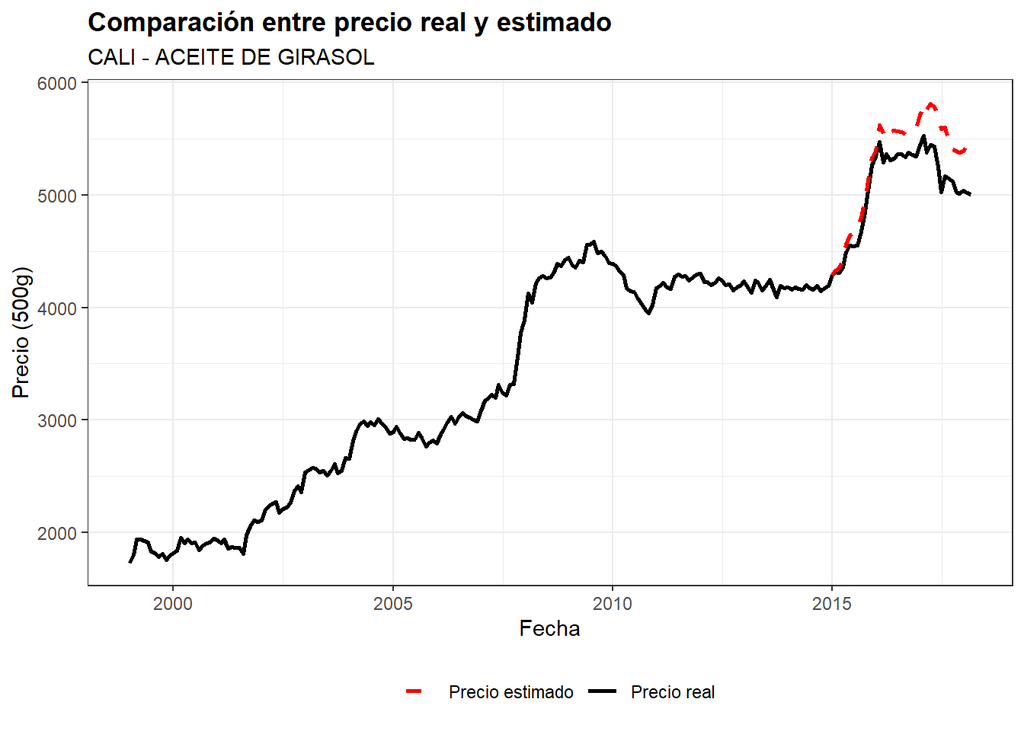

```
## [1] "CALI - ACEITE DE SOYA O DE MAÍZ"
```

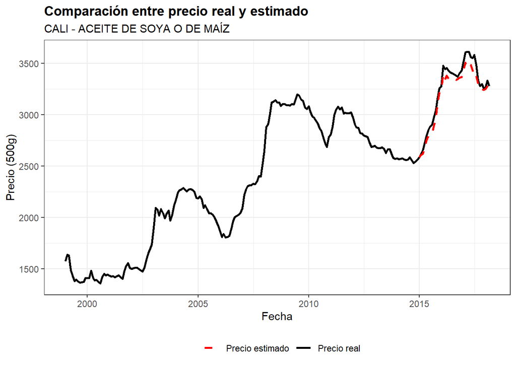

```
## [1] "CALI - AGUA  MINERAL"
```

[figure not shown]

```
## [1] "CALI - AGUACATE"
```

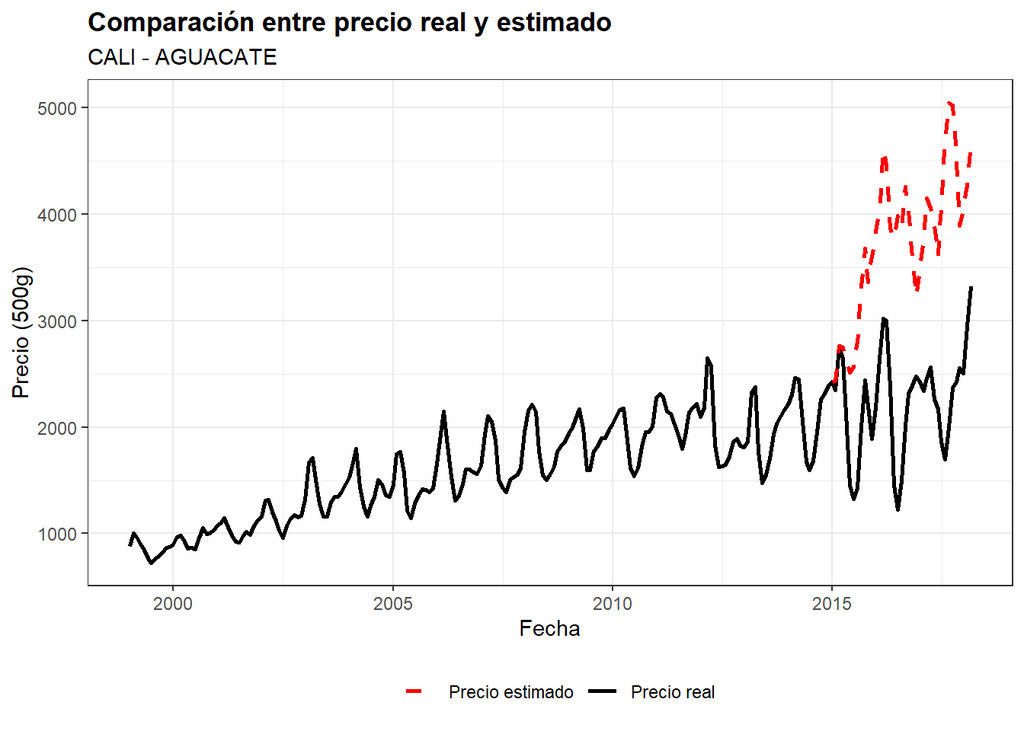

```
## [1] "CALI - AHUYAMA"
```

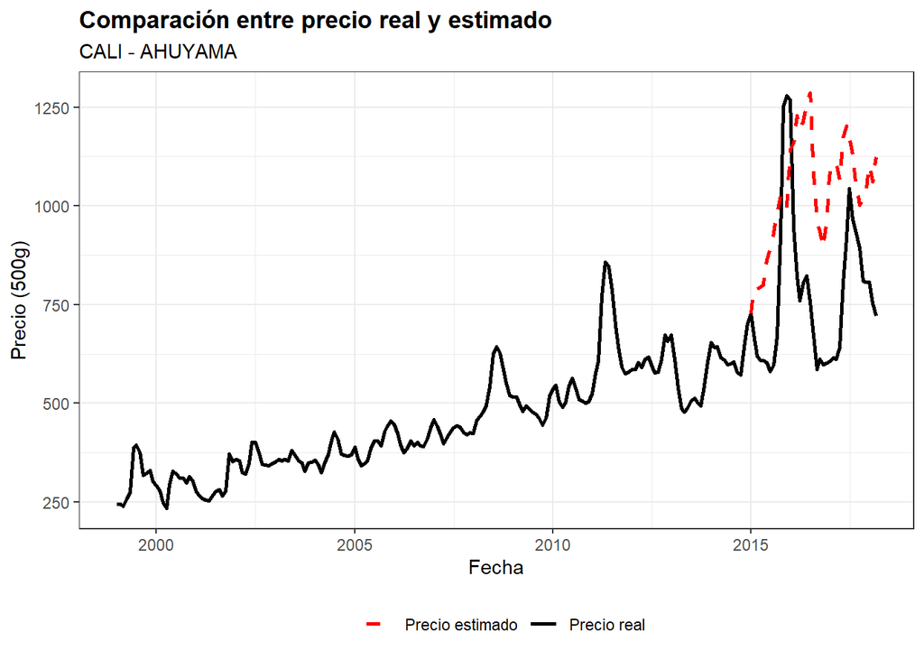

```
## [1] "CALI - AJO"
```

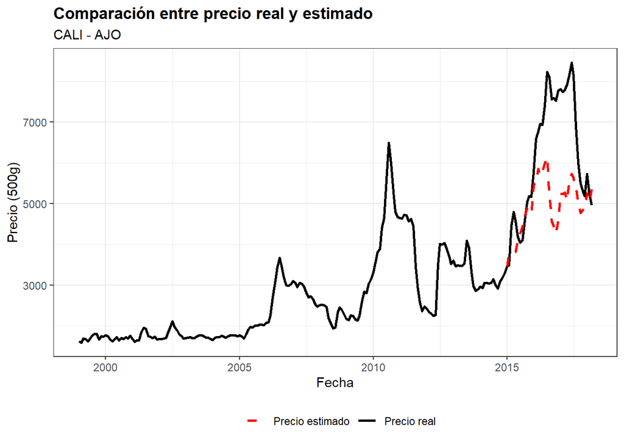

```
## [1] "CALI - ARRACACHA"
```

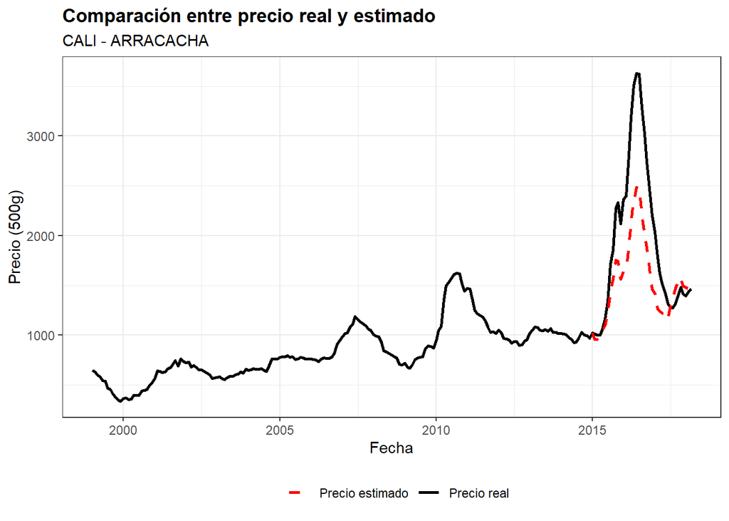

```
## [1] "CALI - ARROZ INTEGRAL"
```

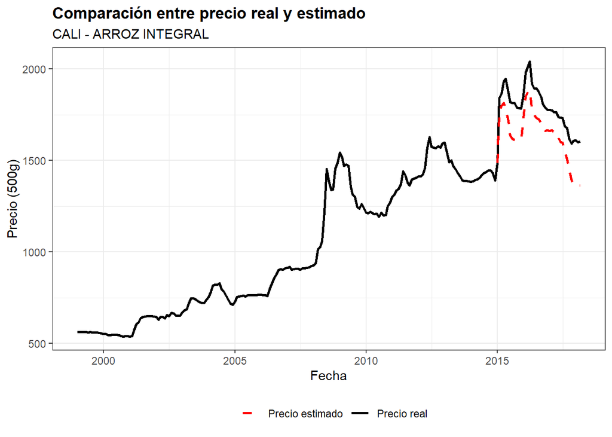

```
## [1] "CALI - ARROZ PARA SECO"
```

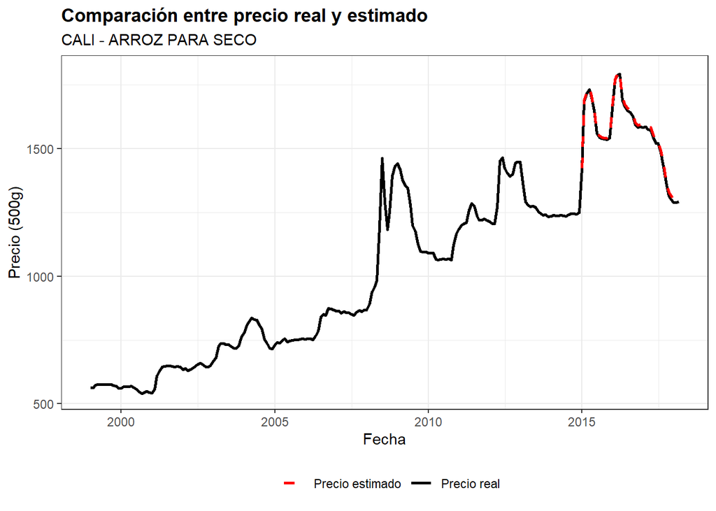

```
## [1] "CALI - ARVEJA FRESCA"
```

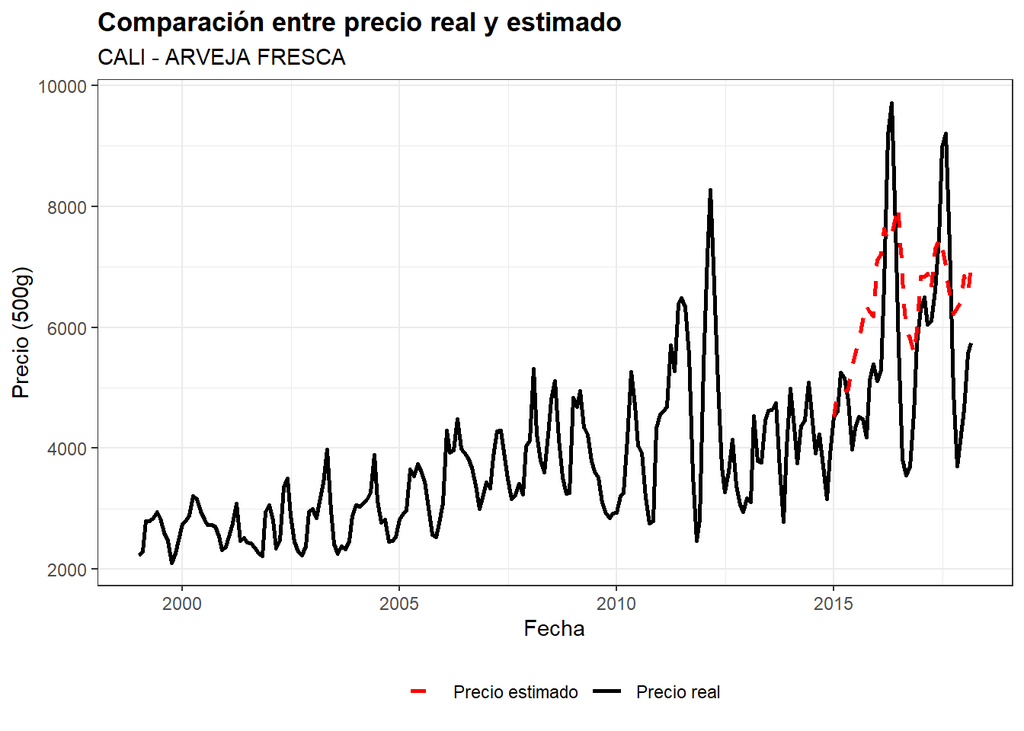

```
## [1] "CALI - ARVEJA SECA"
```

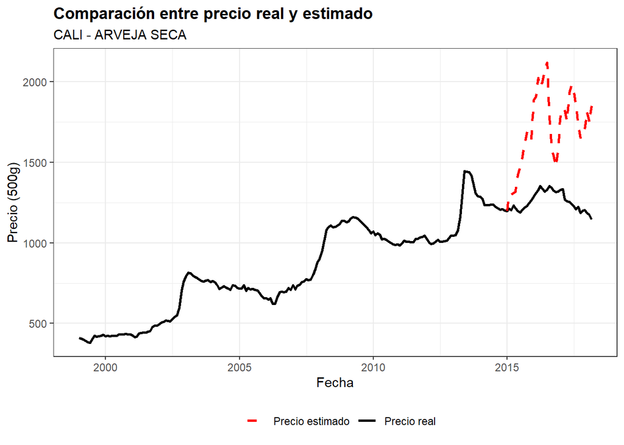

```
## [1] "CALI - ARVEJA TARRO"
```

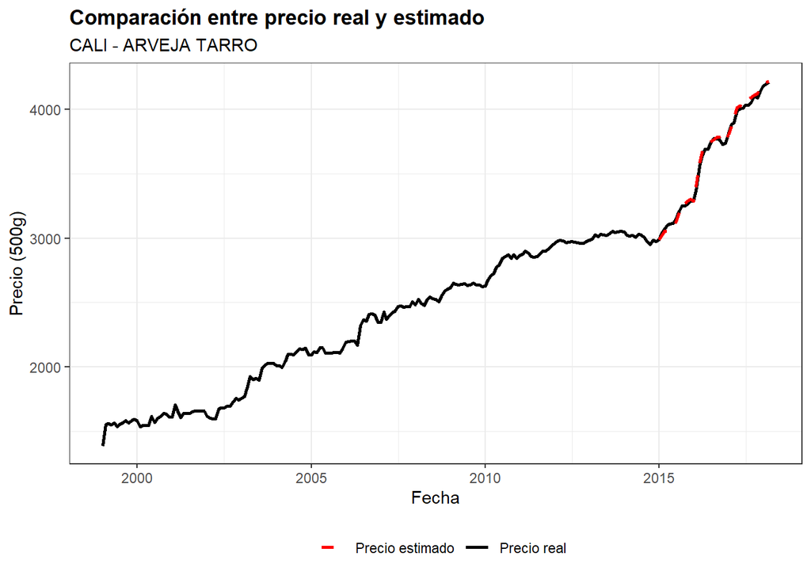

```
## [1] "CALI - AVENA HOJUELAS"
```

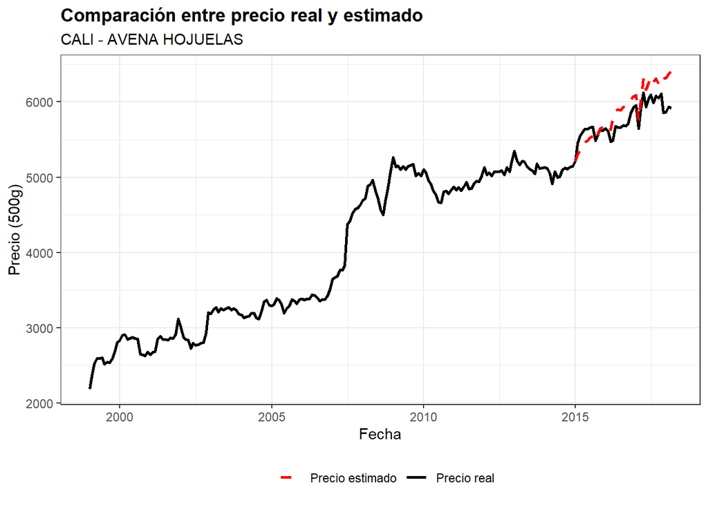

```
## [1] "CALI - AVENA MOLIDA"
```

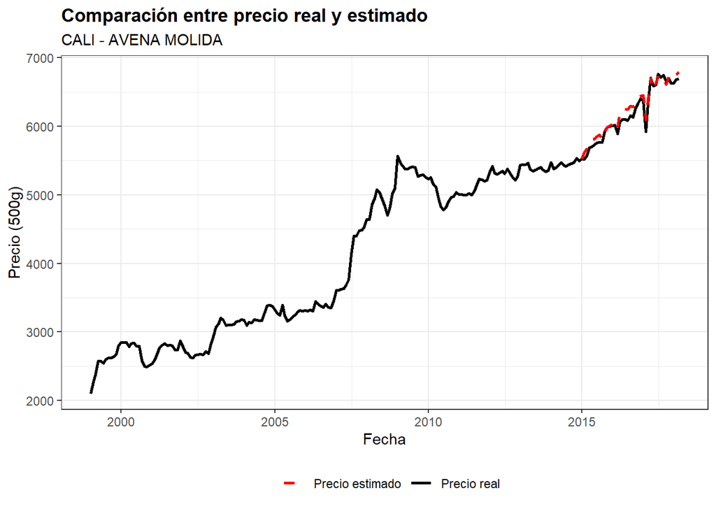

```
## [1] "CALI - AZÚCAR NATURAL O MORENA"
```

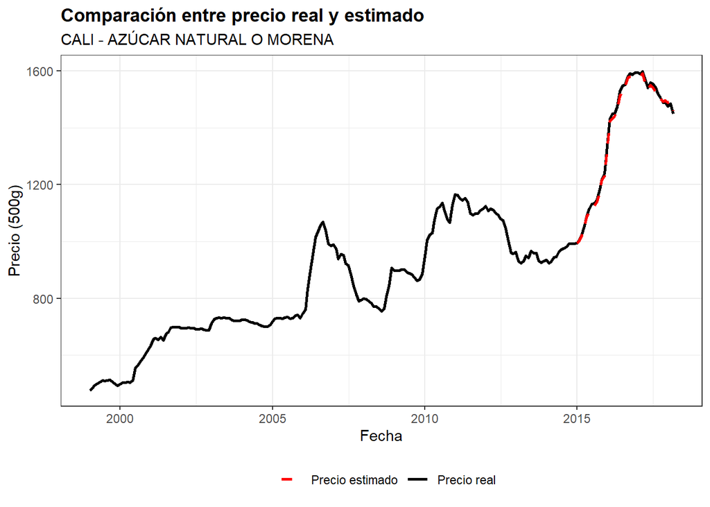

```
## [1] "CALI - AZÚCAR REFINADA"
```

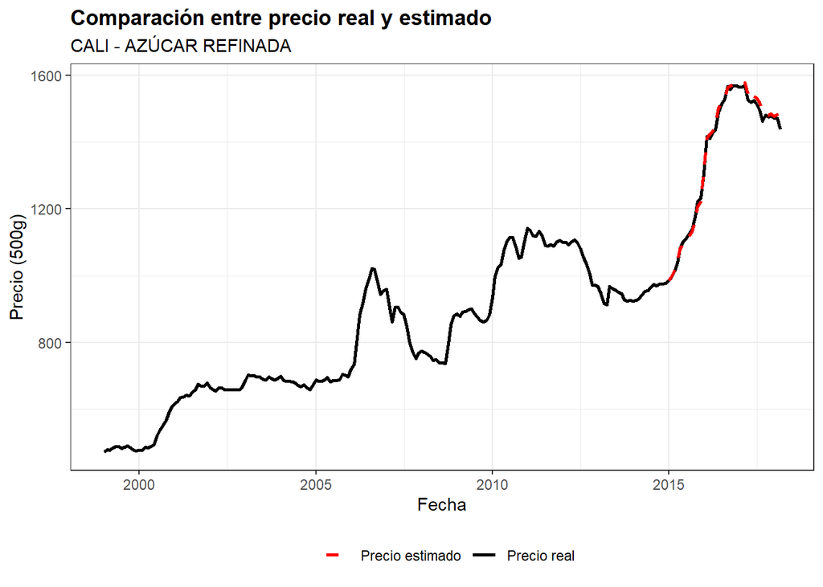

```
## [1] "CALI - BANANOS"
```

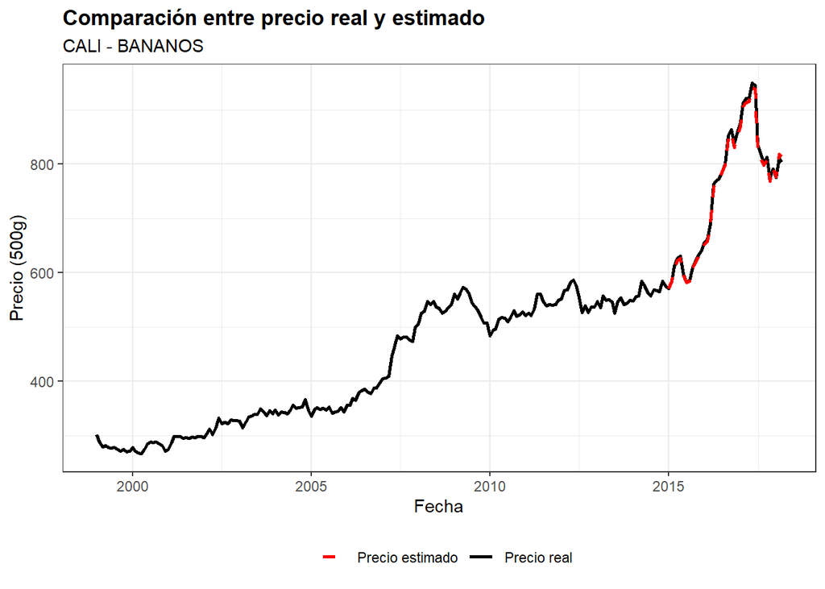

```
## [1] "CALI - CAFÉ MOLIDO"
```

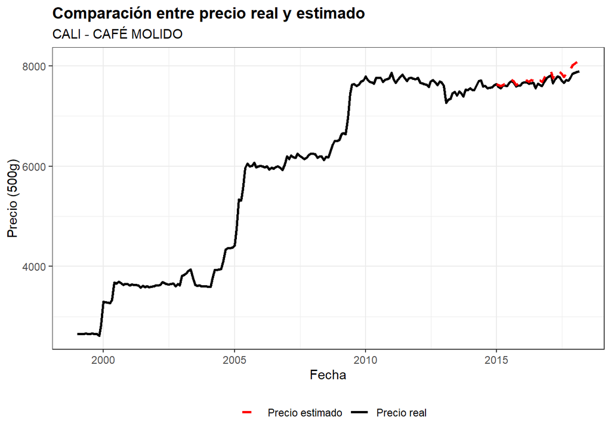

```
## [1] "CALI - CAMARONES O VARIEDAD DISPONIBL"
## [1] "CALI - CAMARONES O VARIEDAD DISPONIBLE"
```

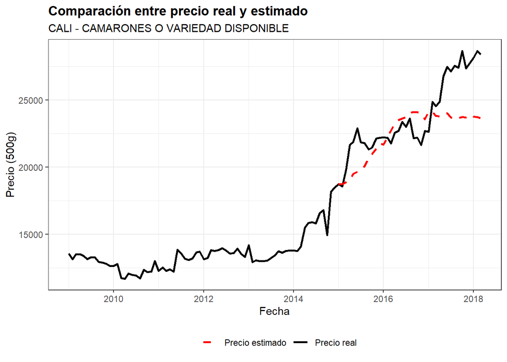

```
## [1] "CALI - CARNE DE CERDO CON HUESO"
```

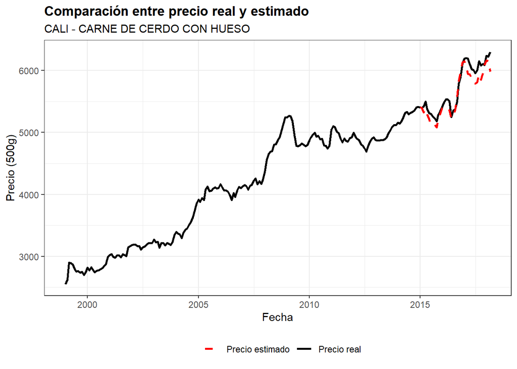

```
## [1] "CALI - CARNE DE CERDO SIN HUESO"
```

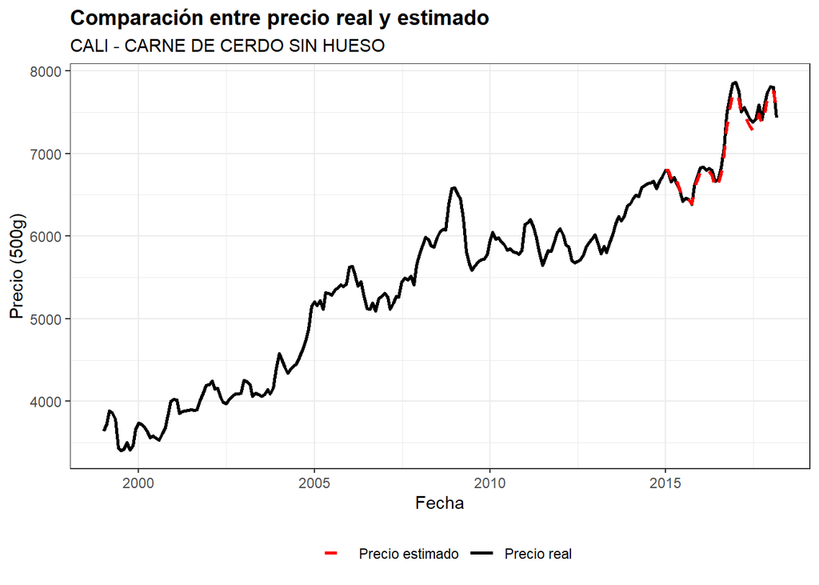

```
## [1] "CALI - CARNE DE RES CON HUESO"
```

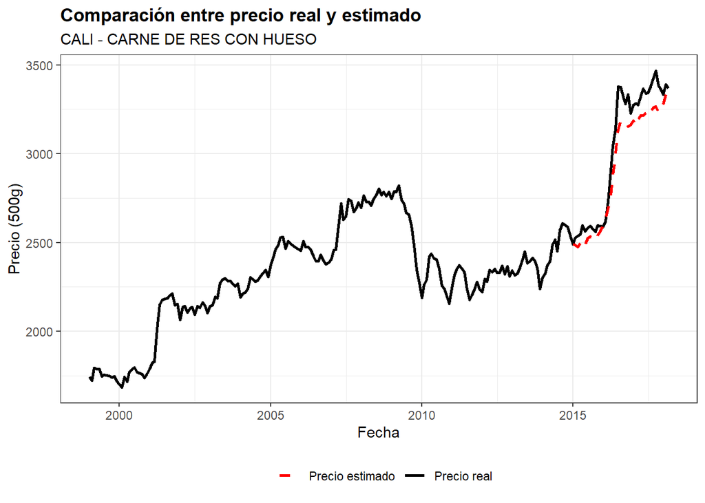

```
## [1] "CALI - CARNE DE RES SIN HUESO"
```

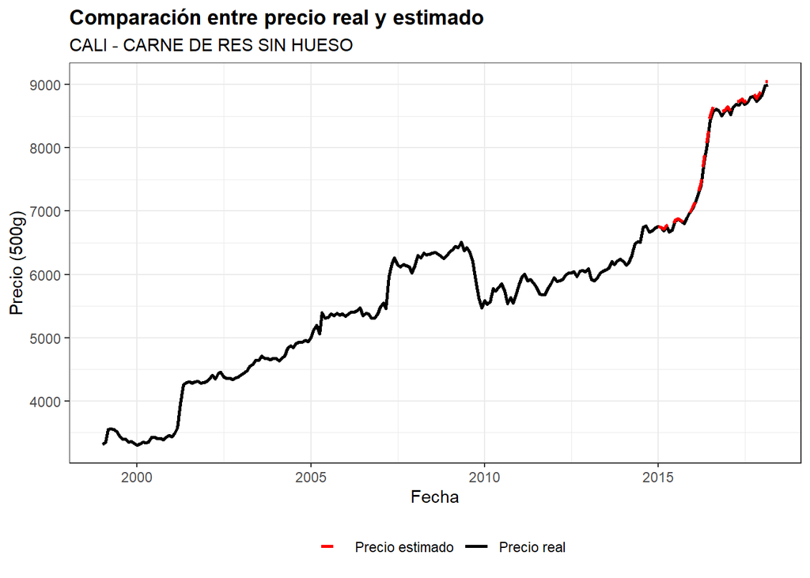

```
## [1] "CALI - CEBOLLA CABEZONA"
```

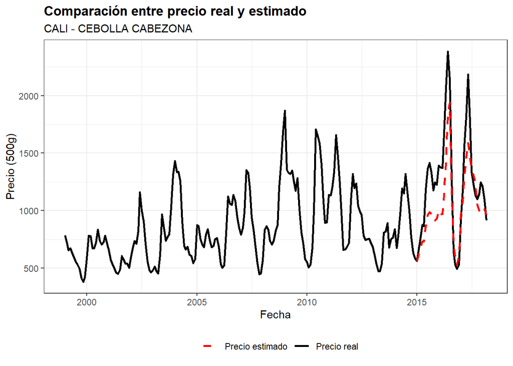

```
## [1] "CALI - CEBOLLA LARGA"
```

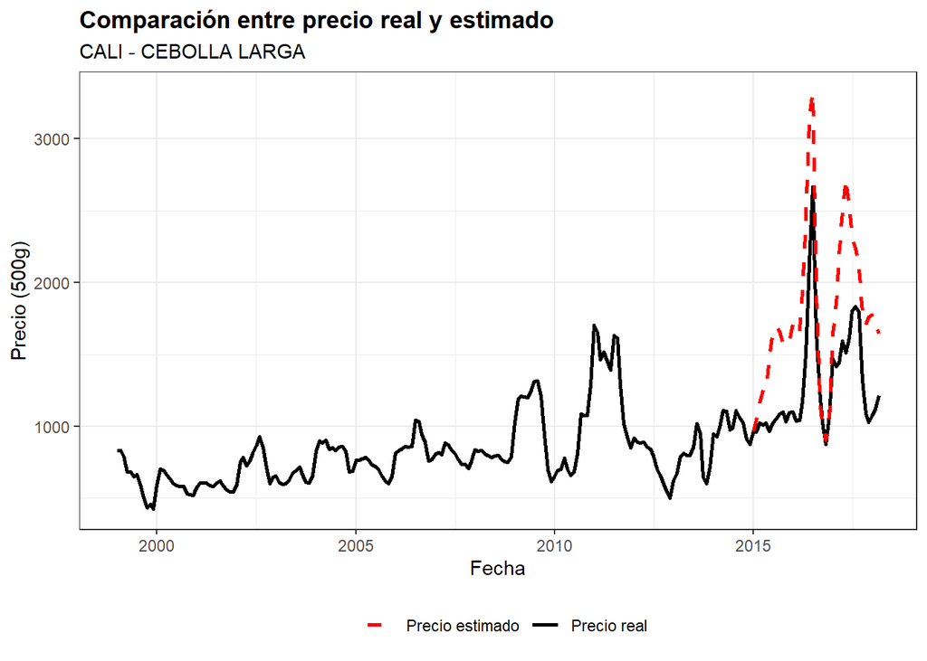

```
## [1] "CALI - CURUBAS"
```

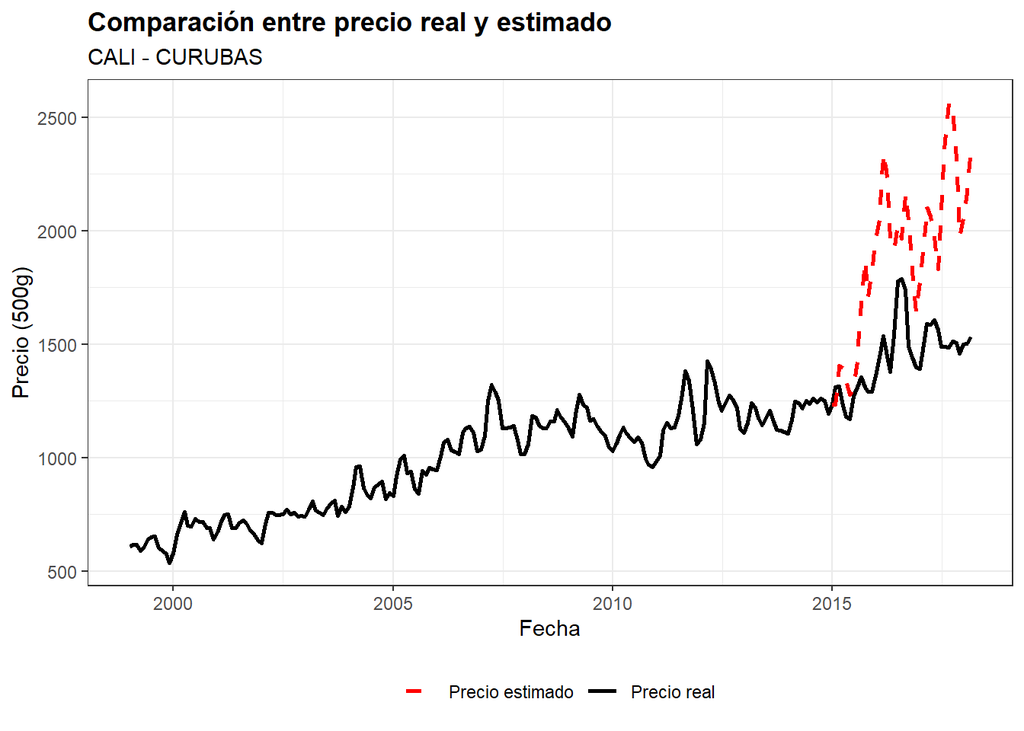

```
## [1] "CALI - FECULA DE MAÍZ"
## [1] "CALI - FRÍJOL FRESCO"
```

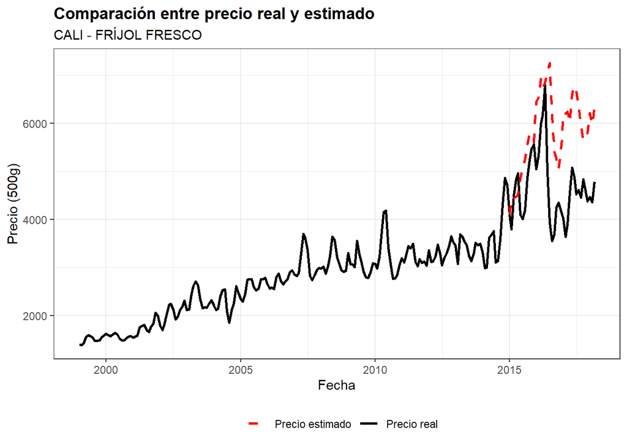

```
## [1] "CALI - FRÍJOL SECO"
```

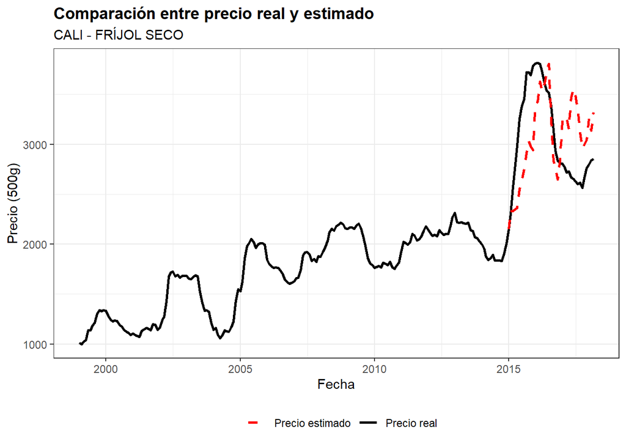

```
## [1] "CALI - FRÍJOL TARRO"
```

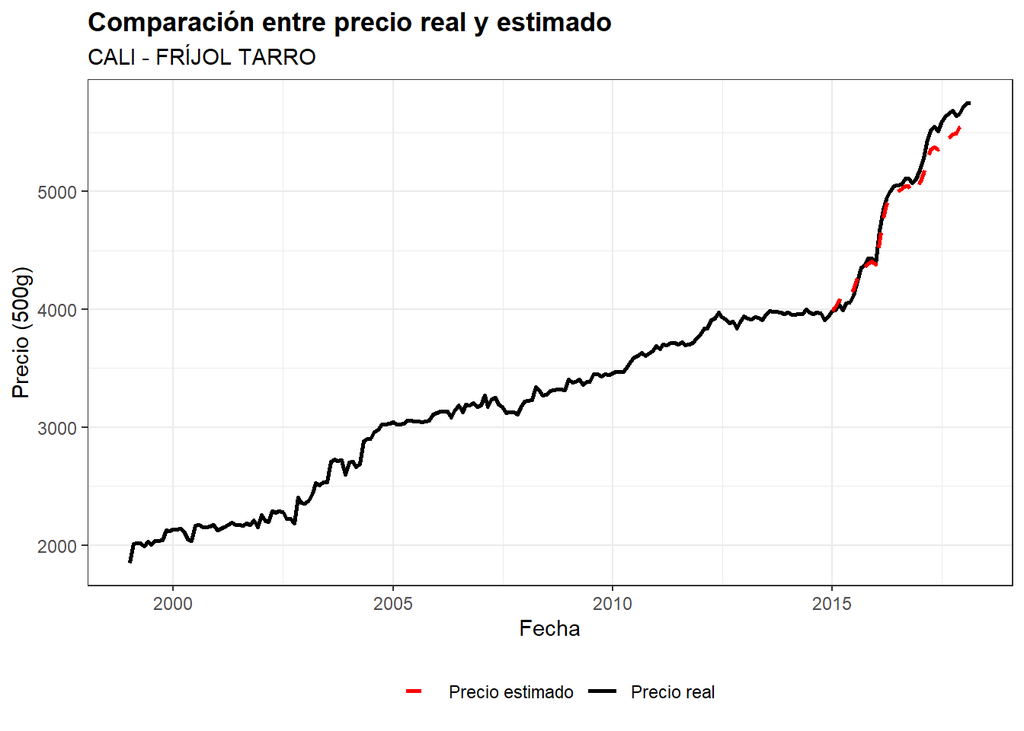

```
## [1] "CALI - GUAYABAS"
```

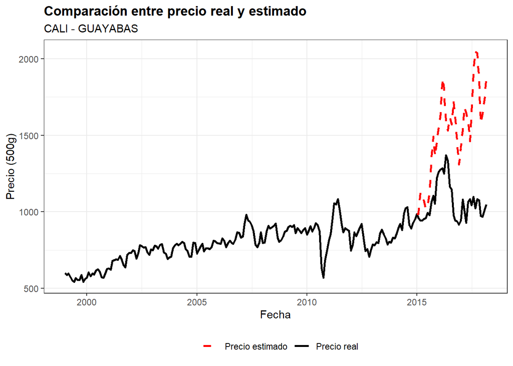

```
## [1] "CALI - HABICHUELAS FRESCAS"
```

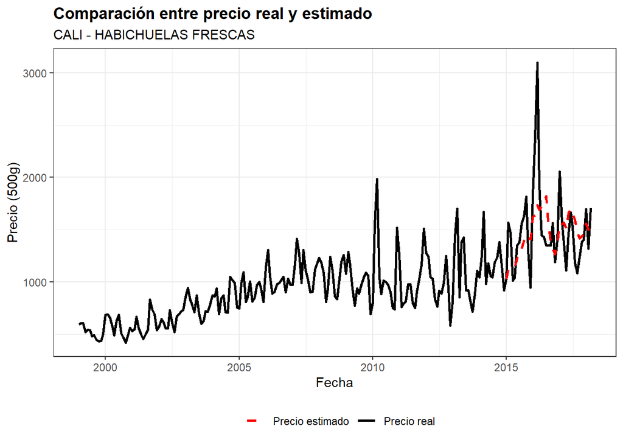

```
## [1] "CALI - HARINA DE TRIGO"
```

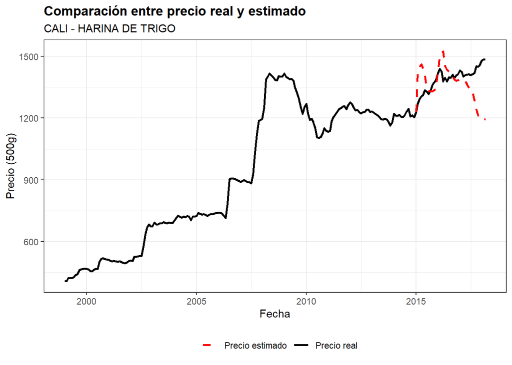